# Exploring Global Food and Feed Production Trends: A Comprehensive Analysis

Nikhitha Gunta

2023-12-08

# Introduction

The provided dataset offers a crucial perspective on global food production, highlighting the balance between food cultivated for human consumption and feed produced for animals. This information is particularly relevant given the projected surge in the world’s population from 7.3 billion to 9.7 billion by 2050. Addressing the challenges of feeding this growing population necessitates innovative approaches in agricultural practices and dietary habits. Moreover, these strategies must be developed in the context of an evolving climate, which both impacts and is impacted by agricultural methods. Analyzing this dataset can provide valuable insights into current production trends and help in formulating sustainable solutions to meet future food demands while considering environmental implications

# Data Acquisition

I acquired the dataset from Kaggle: https://www.kaggle.com/datasets/dorbicycle/world-foodfeed-production/data

```r
# Load necessary libraries
library(tidyverse) # for data manipulation and visualization
```

```r
library(dplyr)  # for data manipulation
library(ggplot2) # for data visualization

# Read in the dataset from the specified location
agriculture_data <- read.csv("E:/FInal Project/FAO.csv")

# Display the structure of the dataframe
str(agriculture_data)
```

```
## 'data.frame':    21477 obs. of  63 variables:
##  $ Area.Abbreviation: chr  "AFG" "AFG" "AFG" "AFG" ...
##  $ Area.Code        : int  2 2 2 2 2 2 2 2 2 2 ...
##  $ Area             : chr  "Afghanistan" "Afghanistan" "Afghanistan" "Afghanistan" ...
##  $ Item.Code        : int  2511 2805 2513 2513 2514 2514 2517 2520 2531 2536 ...
##  $ Item             : chr  "Wheat and products" "Rice (Milled Equivalent)" "Barley and products" "Barley and products" ...
##  $ Element.Code     : int  5142 5142 5521 5142 5521 5142 5142 5142 5142 5521 ...
##  $ Element          : chr  "Food" "Food" "Feed" "Food" ...
##  $ Unit             : chr  "1000 tonnes" "1000 tonnes" "1000 tonnes" "1000 tonnes" ...
##  $ latitude         : num  33.9 33.9 33.9 33.9 33.9 ...
##  $ longitude        : num  67.7 67.7 67.7 67.7 67.7 ...
##  $ Y1961            : int  1928 183 76 237 210 403 17 0 111 45 ...
##  $ Y1962            : int  1904 183 76 237 210 403 18 0 97 45 ...
##  $ Y1963            : int  1666 182 76 237 214 410 19 0 103 45 ...
##  $ Y1964            : int  1950 220 76 238 216 415 20 0 110 45 ...
```

[output cut: 49 more lines]

```r
# Convert from a wide dataset to a long dataset using pivot_longer
agriculture_data_long <- agriculture_data %>%
  pivot_longer(cols = starts_with("Y"),
               names_to = "Year",
               values_to = "Production")

# Display a summary of the long dataset
summary(agriculture_data_long)
```

```
##  Area.Abbreviation    Area.Code         Area             Item.Code
##  Length:1138281     Min.   :  1.0   Length:1138281     Min.   :2511
##  Class :character   1st Qu.: 63.0   Class :character   1st Qu.:2561
##  Mode  :character   Median :120.0   Mode  :character   Median :2640
##                     Mean   :125.4                      Mean   :2694
##                     3rd Qu.:188.0                      3rd Qu.:2782
##                     Max.   :276.0                      Max.   :2961
##
##      Item            Element.Code    Element              Unit
##  Length:1138281     Min.   :5142   Length:1138281     Length:1138281
##  Class :character   1st Qu.:5142   Class :character   Class :character
##  Mode  :character   Median :5142   Mode  :character   Mode  :character
##                     Mean   :5212
##                     3rd Qu.:5142
##                     Max.   :5521
##
##     latitude        longitude           Year             Production
##  Min.   :-40.90   Min.   :-172.10   Length:1138281     Min.   :  -246
##  1st Qu.:  6.43   1st Qu.: -11.78   Class :character   1st Qu.:     0
##  Median : 20.59   Median :  19.15   Mode  :character   Median :     3
##  Mean   : 20.45   Mean   :  15.79                      Mean   :   371
##  3rd Qu.: 41.15   3rd Qu.:  46.87                      3rd Qu.:    49
##  Max.   : 64.96   Max.   : 179.41                      Max.   :489299
##                                                        NA's   :117450
```

```r
str(agriculture_data_long)
```

```
## tibble [1,138,281 × 12] (S3: tbl_df/tbl/data.frame)
##  $ Area.Abbreviation: chr [1:1138281] "AFG" "AFG" "AFG" "AFG" ...
##  $ Area.Code        : int [1:1138281] 2 2 2 2 2 2 2 2 2 2 ...
##  $ Area             : chr [1:1138281] "Afghanistan" "Afghanistan" "Afghanistan" "Afghanistan" ...
##  $ Item.Code        : int [1:1138281] 2511 2511 2511 2511 2511 2511 2511 2511 2511 2511 ...
##  $ Item             : chr [1:1138281] "Wheat and products" "Wheat and products" "Wheat and products" "Wheat and products" ...
##  $ Element.Code     : int [1:1138281] 5142 5142 5142 5142 5142 5142 5142 5142 5142 5142 ...
##  $ Element          : chr [1:1138281] "Food" "Food" "Food" "Food" ...
##  $ Unit             : chr [1:1138281] "1000 tonnes" "1000 tonnes" "1000 tonnes" "1000 tonnes" ...
##  $ latitude         : num [1:1138281] 33.9 33.9 33.9 33.9 33.9 ...
##  $ longitude        : num [1:1138281] 67.7 67.7 67.7 67.7 67.7 ...
##  $ Year             : chr [1:1138281] "Y1961" "Y1962" "Y1963" "Y1964" ...
##  $ Production       : int [1:1138281] 1928 1904 1666 1950 2001 1808 2053 2045 2154 1819 ...
```

```r
# Convert years to integers
agriculture_data_long$Year <- as.integer(gsub("Y", "", agriculture_data_long$Year))

# Remove rows with NA in the Production column
agriculture_data_long <- agriculture_data_long %>%
  drop_na(Production)

# Display a summary of the updated dataset
summary(agriculture_data_long)
```

```
##  Area.Abbreviation    Area.Code         Area             Item.Code
##  Length:1020831     Min.   :  1.0   Length:1020831     Min.   :2511
##  Class :character   1st Qu.: 59.0   Class :character   1st Qu.:2561
##  Mode  :character   Median :117.0   Mode  :character   Median :2641
##                     Mean   :120.4                      Mean   :2694
##                     3rd Qu.:176.0                      3rd Qu.:2782
##                     Max.   :276.0                      Max.   :2961
##      Item            Element.Code    Element              Unit
##  Length:1020831     Min.   :5142   Length:1020831     Length:1020831
##  Class :character   1st Qu.:5142   Class :character   Class :character
##  Mode  :character   Median :5142   Mode  :character   Mode  :character
##                     Mean   :5209
##                     3rd Qu.:5142
##                     Max.   :5521
##     latitude        longitude            Year        Production
##  Min.   :-40.90   Min.   :-172.10   Min.   :1961   Min.   :  -246
##  1st Qu.:  4.21   1st Qu.: -24.01   1st Qu.:1975   1st Qu.:     0
##  Median : 17.06   Median :  17.68   Median :1989   Median :     3
##  Mean   : 17.77   Mean   :  13.60   Mean   :1988   Mean   :   371
##  3rd Qu.: 36.20   3rd Qu.:  46.87   3rd Qu.:2002   3rd Qu.:    49
##  Max.   : 64.96   Max.   : 179.41   Max.   :2013   Max.   :489299
```

```r
# Identify rows where production is negative
rows_with_negative_production <- which(agriculture_data_long$Production < 0)
print(rows_with_negative_production)
```

```
## [1] 493075 493076
```

```r
# Filter out rows with negative production
agriculture_data_filtered <- agriculture_data_long %>%
  filter(Production >= 0)

# Display a summary of the filtered dataset
summary(agriculture_data_filtered)
```

```
##  Area.Abbreviation    Area.Code         Area             Item.Code
##  Length:1020829     Min.   :  1.0   Length:1020829     Min.   :2511
##  Class :character   1st Qu.: 59.0   Class :character   1st Qu.:2561
##  Mode  :character   Median :117.0   Mode  :character   Median :2641
##                     Mean   :120.4                      Mean   :2694
##                     3rd Qu.:176.0                      3rd Qu.:2782
##                     Max.   :276.0                      Max.   :2961
##      Item            Element.Code    Element              Unit
##  Length:1020829     Min.   :5142   Length:1020829     Length:1020829
##  Class :character   1st Qu.:5142   Class :character   Class :character
##  Mode  :character   Median :5142   Mode  :character   Mode  :character
##                     Mean   :5209
##                     3rd Qu.:5142
##                     Max.   :5521
##     latitude        longitude            Year        Production
##  Min.   :-40.90   Min.   :-172.10   Min.   :1961   Min.   :     0
##  1st Qu.:  4.21   1st Qu.: -24.01   1st Qu.:1975   1st Qu.:     0
##  Median : 17.06   Median :  17.68   Median :1989   Median :     3
##  Mean   : 17.77   Mean   :  13.60   Mean   :1988   Mean   :   371
##  3rd Qu.: 36.20   3rd Qu.:  46.87   3rd Qu.:2002   3rd Qu.:    49
##  Max.   : 64.96   Max.   : 179.41   Max.   :2013   Max.   :489299
```

```r
# Select relevant columns for analysis
agriculture_analysis_data <- agriculture_data_filtered %>%
  select(Area,Item,Element,Unit,Year,Production)

# Display a summary of the analysis dataset
summary(agriculture_analysis_data)
```

```
##      Area               Item             Element              Unit
##  Length:1020829     Length:1020829     Length:1020829     Length:1020829
##  Class :character   Class :character   Class :character   Class :character
##  Mode  :character   Mode  :character   Mode  :character   Mode  :character
##
##
##
##       Year        Production
##  Min.   :1961   Min.   :     0
##  1st Qu.:1975   1st Qu.:     0
##  Median :1989   Median :     3
##  Mean   :1988   Mean   :   371
##  3rd Qu.:2002   3rd Qu.:    49
##  Max.   :2013   Max.   :489299
```

```r
# Display unique values in the 'Element' column
unique(agriculture_data_filtered$Element)
```

```
## [1] "Food" "Feed"
```

```r
# Convert 'Element' column to a factor
agriculture_analysis_data<- agriculture_analysis_data %>%
  mutate(Element = factor(Element))

# Aggregate data by Area, Item, Unit, Year, and Element
aggregated_data <- agriculture_analysis_data %>%
  group_by(Area, Item, Unit, Year, Element) %>%
  summarise(Production = sum(Production), .groups = "drop")

# Display a summary of the aggregated data
summary(aggregated_data)
```

```
##      Area               Item               Unit                Year
##  Length:999314      Length:999314      Length:999314      Min.   :1961
##  Class :character   Class :character   Class :character   1st Qu.:1975
##  Mode  :character   Mode  :character   Mode  :character   Median :1989
##                                                           Mean   :1988
##                                                           3rd Qu.:2002
##                                                           Max.   :2013
##  Element         Production
##  Feed:176766   Min.   :     0
##  Food:822548   1st Qu.:     0
##                Median :     3
##                Mean   :   379
##                3rd Qu.:    47
##                Max.   :489299
```

```r
# Pivot the data to wider format for better visualization
aggregated_data <- pivot_wider(
  data = aggregated_data,
  names_from = Element,
  values_from = Production,
  values_fill = 0
)
```

EXPLORATORY DATA ANALYSIS

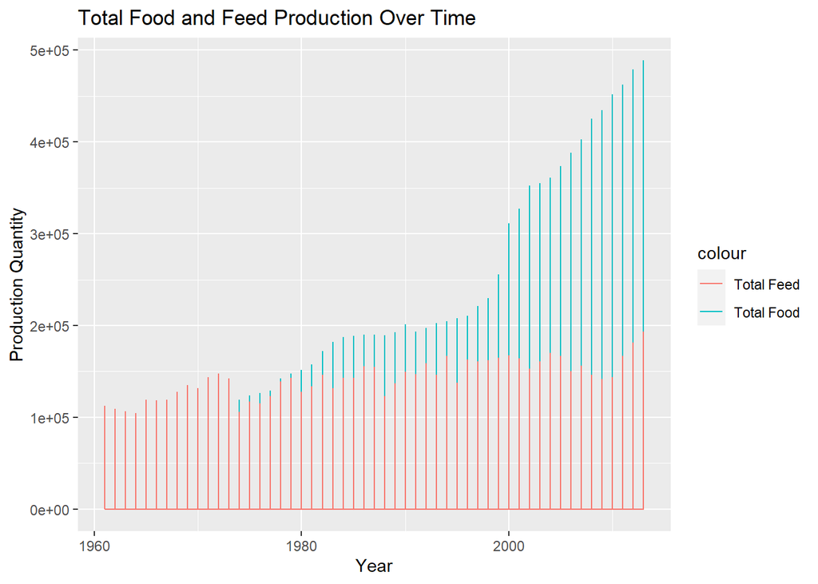

```r
# Visualize the trends of Food and Feed production over time
ggplot(aggregated_data, aes(x = Year)) +
  geom_line(aes(y = Food, color = "Total Food")) +
  geom_line(aes(y = Feed, color = "Total Feed")) +
  labs(title = "Total Food and Feed Production Over Time",
       x = "Year", y = "Production Quantity")
```

#The data shows that food production has gone up a lot more than feed production over these years. There’s a big difference in how much food and feed we produce

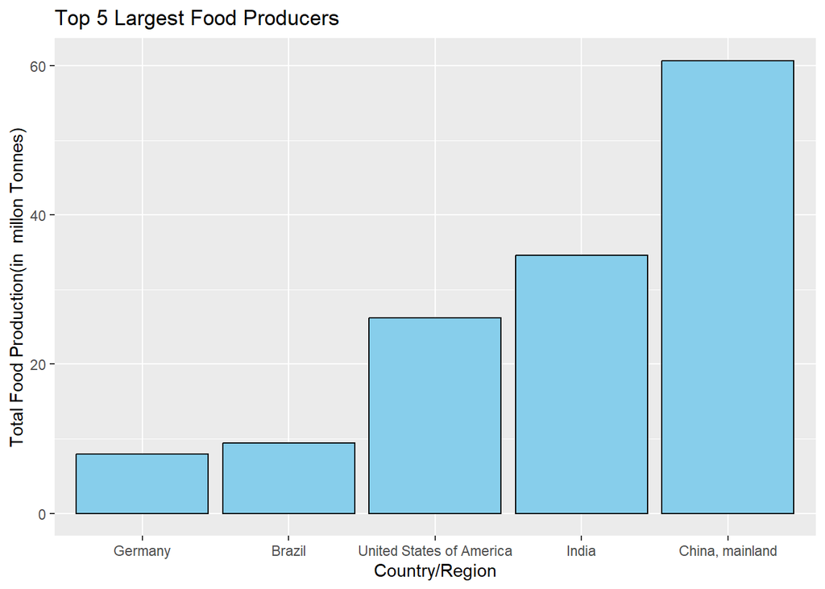

China, India, and the USA are the largest food producers. Among the top five, Germany and Brazil contribute the smallest amounts.

```r
#Top 5 food producers since 1961

# Calculate top 5  food producers

largest_food_producers <- aggregated_data %>%
  group_by(Area) %>%
  summarize(Food = sum(Food, na.rm = TRUE)) %>%
  arrange(desc(Food))

# Display the top 5 largest food producers
top_n_producers <- 5
top_food_producers <- head(largest_food_producers, n = top_n_producers)

# Convert production to million tons for visualization
top_food_producers$Total_Food_Million_Tons <- top_food_producers$Food / 1e6

# Visualize the top 5 food producers in a bar chart
ggplot(top_food_producers, aes(x = reorder(Area, Total_Food_Million_Tons), y = Total_Food_Million_Tons)) +
  geom_bar(stat = "identity", fill = "skyblue", color = "black") +
  labs(title = paste("Top", top_n_producers, "Largest Food Producers"),
       x = "Country/Region", y = "Total Food Production(in  millon Tonnes)")
```

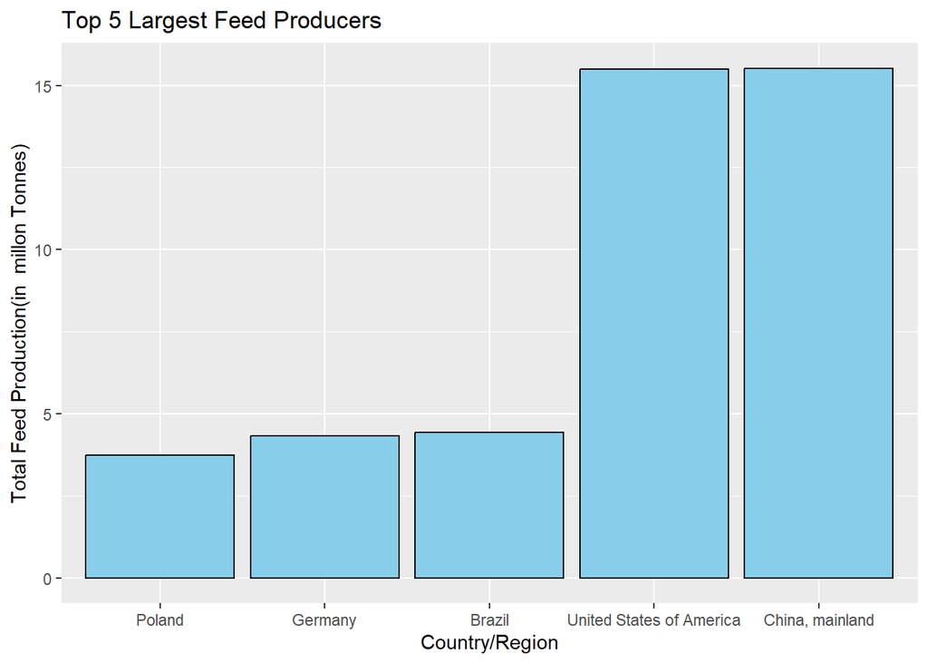

The United States and China top the list as the biggest producers of animal feed, with Poland, Germany, and Brazil lagging behind with significantly smaller production volumes.

```r
# Similar steps for largest feed producers
largest_feed_producers <- aggregated_data %>%
  group_by(Area) %>%
  summarize(Feed = sum(Feed, na.rm = TRUE)) %>%
  arrange(desc(Feed))

# Display the top N largest food producers (e.g., top 5)
top_n_producers <- 5
top_feed_producers <- head(largest_feed_producers, n = top_n_producers)

# Convert production to million tons
top_feed_producers$Total_Feed_Million_Tons <- top_feed_producers$Feed / 1e6

# Visualization (bar chart)
ggplot(top_feed_producers, aes(x = reorder(Area, Total_Feed_Million_Tons), y = Total_Feed_Million_Tons)) +
  geom_bar(stat = "identity", fill = "skyblue", color = "black") +
  labs(title = paste("Top", top_n_producers, "Largest Feed Producers"),
       x = "Country/Region", y = "Total Feed Production(in  millon Tonnes)")
```

```r
# Filter data for 'Food' element
food_data <- agriculture_analysis_data %>% filter(Element == "Food")

# Group by item, calculate the total production for each item
item_production <- food_data %>%
  group_by(Item) %>%
  summarize(Total_Production = sum(Production, na.rm = TRUE)) %>%
  arrange(desc(Total_Production)) %>%
  head(5)  # Select the top 5 items

# Filter the original data for the top 10 food items
top_food_data <- food_data %>% filter(Item %in% item_production$Item)

top_food_data_aggregated <- top_food_data %>%
  group_by(Year, Item) %>%
  summarize(Total_Production = sum(Production, na.rm = TRUE))
```

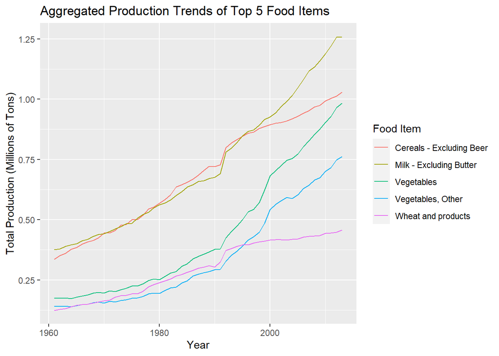

Since 1961, cereals and milk have topped the charts as the food items with the highest production.

```r
# Create a line plot for the aggregated production of top food items
ggplot(top_food_data_aggregated, aes(x = Year, y = Total_Production/1e6, color = Item)) +
  geom_line() +
  labs(title = "Aggregated Production Trends of Top 5 Food Items",
       x = "Year", y = "Total Production (Millions of Tons)",
       color = "Food Item") +
  theme(legend.position = "right")
```

#We will now investigate the leading items produced for animal feed

```r
# Filter data for 'Feed' element
feed_data <- agriculture_analysis_data %>% filter(Element == "Feed")

# Group by item, calculate the total production for each item
item_production_feed <- feed_data %>%
  group_by(Item) %>%
  summarize(Total_Production = sum(Production, na.rm = TRUE)) %>%
  arrange(desc(Total_Production)) %>%
  head(5)  # Select the top 10 items

# Filter the original data for the top 10 feed items
top_feed_data <- feed_data %>% filter(Item %in% item_production_feed$Item)

top_feed_data_aggregated <- top_feed_data %>%
  group_by(Year, Item) %>%
  summarize(Total_Production = sum(Production, na.rm = TRUE))
```

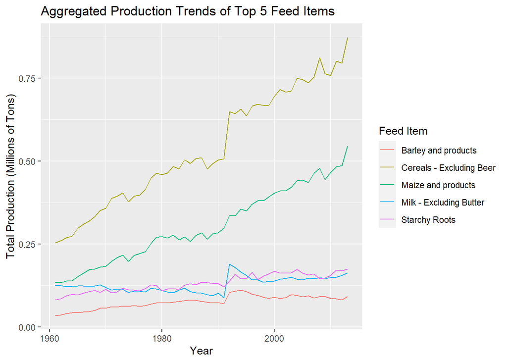

The production of cereals and maize as feed has sharply increased since the 1980s, while other feed items like barley, milk, and starchy roots have seen only modest growth.

```r
# Create a line plot for the aggregated production of top feed items
ggplot(top_feed_data_aggregated, aes(x = Year, y = Total_Production/1e6, color = Item)) +
  geom_line() +
  labs(title = "Aggregated Production Trends of Top 5 Feed Items",
       x = "Year", y = "Total Production (Millions of Tons)",
       color = "Feed Item") +
  theme(legend.position = "right")
```